# project_bank_churn

# Comment on Model 3 performance

# Model Improvement - Model 4

- Keep the changes in Model 3
- Lets just increase the dense layers to 65.

```python
model = keras.Sequential([
    keras.layers.Dense(65,
                       input_shape=(num_input_features,),
                       kernel_initializer='he_normal',
                       activation=dense_activation_type),
    keras.layers.Dense(65, activation=dense_activation_type,kernel_initializer='he_normal'),
    keras.layers.Dense(num_output_layers,activation=output_activation_type,kernel_initializer='he_normal')
])
model.compile(optimizer=optimizer_type,
              loss=loss_function_type,
              metrics=[metric_type])
history=model.fit(X_train, y_train, epochs=200,validation_split=0.2)
```

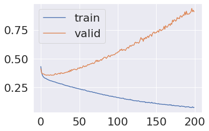

```python
plot_train_vs_val(history)
```

# Comment on Model 4 performance

- Well, seems like we made it worse.Definitely, not the model to use.
- Training accuracy is ~0.97 (which has increased) and valedation accuracy is 0.82 (but still this model is unusable)

# Model Improvement - Model 5

- Keep the changes in model 4
- we will introduce batch normalization and see if it helps with the **over fitting problem**.

```python
model = keras.Sequential([
    keras.layers.Dense(65,
                       input_shape=(num_input_features,),
                       kernel_initializer='he_normal',
                       activation=dense_activation_type),
    keras.layers.BatchNormalization(),
    keras.layers.Dense(65, activation=dense_activation_type,kernel_initializer='he_normal'),
    keras.layers.BatchNormalization(),
    keras.layers.Dense(num_output_layers,activation=output_activation_type,kernel_initializer='he_normal')
])
model.compile(optimizer=optimizer_type,
              loss=loss_function_type,
              metrics=[metric_type])
history=model.fit(X_train, y_train, epochs=200,validation_split=0.2)
```

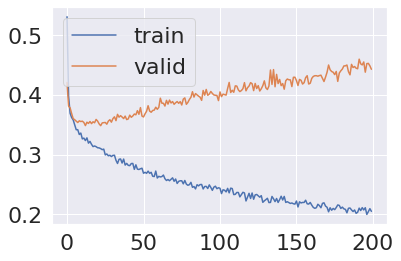

```python
plot_train_vs_val(history)
```

# Comment on Model 5 performance

- Ok, batch normalization is definitely not helping either.
- Training accuracy is ~0.91 (which has increased) and valiwdation accuracy is ~ 0.83 (but still this model is unusable)

# Model Improvement - Model 6

- Keep the changes in model 5
- Also add layers of dropout (instead of batch normalization) and see if it helps in overfitting.

```python
model = keras.Sequential([
    keras.layers.Dense(65,
                       input_shape=(num_input_features,),
                       kernel_initializer='he_normal',
                       activation=dense_activation_type),
    keras.layers.Dropout(0.5),
    keras.layers.Dense(65, activation=dense_activation_type,kernel_initializer='he_normal'),
    keras.layers.Dropout(0.5),
    keras.layers.Dense(num_output_layers,activation=output_activation_type,kernel_initializer='he_normal')
])
model.compile(optimizer=optimizer_type,
              loss=loss_function_type,
              metrics=[metric_type])
history=model.fit(X_train, y_train, epochs=200,validation_split=0.2)
```

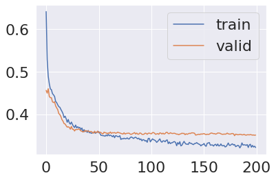

```python
plot_train_vs_val(history)
```

# Comment on Model 6 performance

# Model Improvement - Model 7

- Keep the changes in model 6
- Add the batch normalization again and see if it can improve the previous model

```python
model = keras.Sequential([
    keras.layers.Dense(65,
                       input_shape=(num_input_features,),
                       kernel_initializer='he_normal',
                       activation=dense_activation_type),
    keras.layers.Dropout(0.5),
    keras.layers.BatchNormalization(),
    keras.layers.Dense(65, activation=dense_activation_type,kernel_initializer='he_normal'),
    keras.layers.Dropout(0.5),
    keras.layers.BatchNormalization(),
    keras.layers.Dense(num_output_layers,activation=output_activation_type,kernel_initializer='he_normal')
])
model.compile(optimizer=optimizer_type,
              loss=loss_function_type,
              metrics=[metric_type])
history=model.fit(X_train, y_train, epochs=200,validation_split=0.2)
```

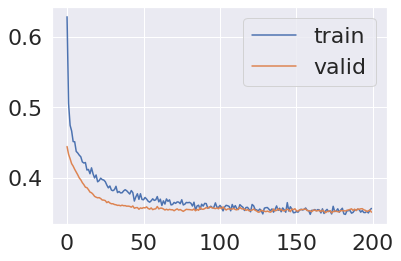

```python
plot_train_vs_val(history)
```

# Comment on Model 7 performance

# Model Performance Evaluation with Model 7

```python
threshold=0.25
y_pred = model.predict(X_test)
for i in range(len(y_test)):
    if y_pred[i]>=threshold:
        y_pred[i]=1
    else:
        y_pred[i]=0
recall,precision,f1_score=estimate_performance_metric(y_test,y_pred)

print(f"Recall_score:{recall}")
print(f"precision_score:{precision}")
print(f"f1_score:{f1_score}")
```

```
Recall_score:0.7382716049382716
precision_score:0.5292035398230088
f1_score:0.6164948453608248
```

# Model Performance Evaluation - Discussion

- with 0.25 threshold, we get a recall score of ~0.75, which is not bad.
- This model **can help a lot in reducing false negatives** (which is very important for business to retain customers).
- The F1 score is around ~ 0.6, this is not ideal, but in the interest of a better recall score, we should just live with this.

# Conclusion and key takeaways

- Data seems to indicate that older folks tend to churn more than the younger members.
  - We could think of promotional offers for older members.
  - Also the product team can work on "special retirement savings plan", which will give a strong reason for the older members to stay with the bank.
- Data seems to indicate that Germany customers are the ones who exited more:
  - The french customers are the ones who least left the bank, but the german customers are the ones who have been exiting a lot realtively.
  - The research team can look into this geographical difference between the 2 and help find the root cause of the issue in germany. For example, may be we have a strong local compeition (from an other bank?).
  - Perhaps try promoting new automobile loans in Germany?, since german automobile industry has been booming lately.
- Data seems to indicate that female members have exited more than the male members:
  - This is something research team can look into. For example, female members can get yearly bonus, if their job is into STEM or health care sector?.
- Lesser active members
  - Data indicates, lesser active members have exited more than active folks.
  - Potential solution for this: If a person is not active for atleast 3 months, start reaching out to them through emails and phone calls. Our promotional offers etc could be conveyed through these contacts. Or it could be simple phone call on "what could be better for them to stay".
- Customers with Higher balance
  - Data seems to indicate that, customers with higher balance have exited more compared to lower balance customers.
  - I think, they probably got into an other bank with better savings rate. and naturally anyone will want to leave the current bank.
  - The research team should relook into our current saving rate, and how it compares to our competition.
- **Please user model 7:**
  - Last but not the least, the customer interaction should use model 7 above (with threshold of 0.25) to predict if a customer will exit or not.